# scRNAseq_EpiGIFT_Seurat_InvestigationCompare_pvalue

Last modification : 30 May, 2023

Laëtitia Racine & Giota Kyratzi

2023-05-30

```r
library(dplyr)
library(Seurat)
library(stringr)
library(ggplot2)
library(ggVennDiagram)
library(kableExtra)
```

```r
# Load working directories
# directory = str_extract(string = getwd(), pattern = "[:graph:]+(?=bin)")
# directory_data = paste0(directory, "data/")
start_time = Sys.time()
current_date = format(Sys.time(), "%Y%m%d")
# dir.create(path = paste0(directory, "exp/scRNAseq_EpiGIFT_Seurat_InvestigationCompare_pvalue/"))
# dir.create(path = paste0(directory, "exp/scRNAseq_EpiGIFT_Seurat_InvestigationCompare_pvalue/",
#                          current_date))
# directory_output = paste0(directory, "exp/scRNAseq_EpiGIFT_Seurat_InvestigationCompare_pvalue/",
#                           current_date, "/")

# Load external script with functions and constants
# source(file = paste0(directory, "bin/", "Epi_FM_functions_constants.R"))

# Define a color code for list category
color_code = c(
  "common_FM_EG" = "#6922FB",
  "only_EG" = "#F73131",
  "only_FM" = "#2E9EFF"
)
```

# Script’s objective and reminder of previous analysis

This code aims at visualizing the pvalue distribution (pvalue calculated with FindMarkers method (=Wilcoxon statistical test) confronted to pvalue calculated with EpiGIFT method)  
Investigate if pvalue of common genes are smaller than one of non common genes.

Abbreviations :  
- FM = FindMarkers() function, classical Seurat analysis based on fold change of average  
- EG = EpiGIFT method, new analysis based on each individual

```r
# genes_EG_list = read.csv2(paste0(directory_data, "20230309_EpiGift_Variable174Genes_pSNP5gt40.csv"), sep =",")
#
# dir1 = pic_last_dir(paste0(directory, "exp/", "scRNAseq_EpiGIFT_Seurat_InvestigationGenesSeurat/"))
# genes_FM_list = readRDS(paste0(dir1, "/", "list_219_genes_FindMarkers_th0.15_wilcox_pval0.05.rds"))
# genes_FM_list = genes_FM_list[["wilcox"]]

# Giota's direcrtory
genes_FM_list <- readRDS("/shared/ifbstor1/projects/strength_field_u/Epigenetics/FindMarkers_th0.15_pval0.05_genes.rds")
genes_EG_list <- read.csv("/shared/ifbstor1/projects/strength_field_u/Epigenetics/list_174genes_pSNP5gt40.csv")
common_list <- genes_EG_list$GeneName[genes_EG_list$GeneName %in% genes_FM_list$gene]
only_EG_list <- setdiff(genes_EG_list$GeneName, genes_FM_list$gene)
only_FM_list <- setdiff(genes_FM_list$gene, genes_EG_list$GeneName)

# dir2 = pic_last_dir(paste0(directory, "exp/", "scRNAseq_EpiGIFT_Seurat_InvestigationCompare_ListGenes/"))
# common_list = readRDS(paste0(dir2, "/", "list_genes_CTRL-DON_commonEGFM.rds"))
# only_FM_list = readRDS(paste0(dir2, "/", "list_genes_CTRL-DON_onlyFM.rds"))
# only_EG_list = readRDS(paste0(dir2, "/", "list_genes_CTRL-DON_onlyEG.rds"))
```

```r
cat("CTRL versus DON : \n",
    "FindMarkers - Seurat :",  nrow(genes_FM_list), "genes \n",
    "EpiGIFT :", nrow(genes_EG_list), "genes \n",
    "Common genes :", length(common_list), "\n",
    "Only FindMarkers :", length(only_FM_list), "\n",
    "Only EpiGift :", length(only_EG_list), "\n")
```

```
## CTRL versus DON :
##  FindMarkers - Seurat : 219 genes
##  EpiGIFT : 174 genes
##  Common genes : 77
##  Only FindMarkers : 142
##  Only EpiGift : 97
```

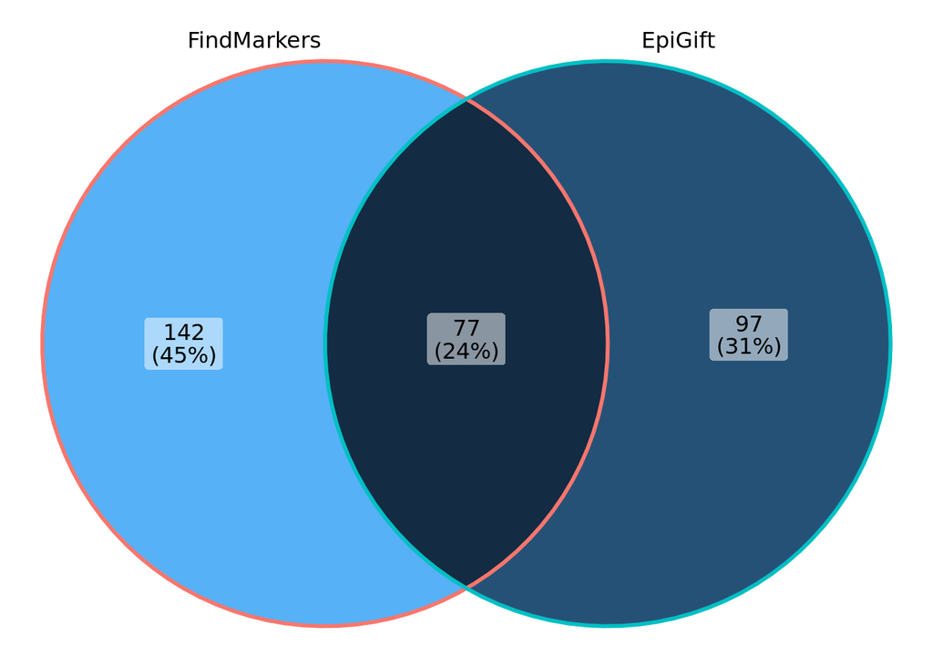

```r
# change color to correspond to color code
ggVennDiagram(x = list(FindMarkers= genes_FM_list$gene,
                       EpiGift= genes_EG_list$GeneName)) +
  theme(legend.position = "none")
```

```r
genes_EG_list = genes_EG_list %>%
  dplyr::mutate(list_category = case_when(GeneName %in% common_list ~ "common_FM_EG",
                                          GeneName %in% only_EG_list ~ "only_EG",
                                          GeneName %in% only_FM_list ~ "only_FM"))

genes_FM_list = genes_FM_list %>%
  dplyr::mutate(list_category = case_when(gene %in% common_list ~ "common_FM_EG",
                                          gene %in% only_EG_list ~ "only_EG",
                                          gene %in% only_FM_list ~ "only_FM"))
```

# pValue distribution of list of genes extracted with FindMarkers method (219 genes)

With FindMarkers method, the p-value is calculated with a Wilcoxon Rank Sum test and is adjusted with Bonferroni correction.

```r
print("pval summary for FM list of genes")
```

```
## [1] "pval summary for FM list of genes"
```

```r
summary(genes_FM_list$p_val)
```

```
##      Min.   1st Qu.    Median      Mean   3rd Qu.      Max.
## 0.000e+00 0.000e+00 0.000e+00 1.504e-08 0.000e+00 2.016e-06
```

```r
print("pval adjusted summary for FM list of genes")
```

```
## [1] "pval adjusted summary for FM list of genes"
```

```r
summary(genes_FM_list$p_val_adj)
```

```
##      Min.   1st Qu.    Median      Mean   3rd Qu.      Max.
## 0.0000000 0.0000000 0.0000000 0.0003321 0.0000000 0.0445256
```

The p-values is a probability number range from 0 to 1.
For visualization purposes we change the scale of the plots and calculate the $-\log(p_{adj})$. We use an epsilon value small enough ($1e-300$) to avoid non-real (Inf) values:
$$\tilde p_{adj} =
-\log(p_{adj}+\epsilon)$$

We use $\epsilon = 1e-300$ since the smallest non-zero values for $p_{adj}$ range down to $1e-300$. So any epsilon value larger than this, i.e $\epsilon = 1e-10$ which is a small value, in our case can be considered large enough to change the transformed p-values.

```r
genes_FM_list = genes_FM_list %>%
  dplyr::mutate(minus_log_p_val_adj = -log(p_val_adj))

print("-log(pval adjusted) summary for FM list of genes")
```

```
## [1] "-log(pval adjusted) summary for FM list of genes"
```

```r
summary(genes_FM_list$minus_log_p_val_adj)
```

```
##    Min. 1st Qu.  Median    Mean 3rd Qu.    Max.
##   3.112  33.048  52.733     Inf 110.477     Inf
```

```r
# Define an epsilon value (small enough) to use on the transformation of the -log
# to avoid non-real values (inf values)
eps <- 1e-300

genes_FM_list = genes_FM_list %>%
  dplyr::mutate(minus_log_p_val_adj_eps = -log(p_val_adj+eps))

print("-log(pval adjusted+eps) summary for FM list of genes")
```

```
## [1] "-log(pval adjusted+eps) summary for FM list of genes"
```

```r
summary(genes_FM_list$minus_log_p_val_adj_eps)
```

```
##    Min. 1st Qu.  Median    Mean 3rd Qu.    Max.
##   3.112  33.048  52.733 112.386 110.477 690.775
```

We order the data in ascending order depending on $p_{adj}$ value.

```r
# Reorder rows by ascending order of pvalue adjusted
genes_FM_list = genes_FM_list %>% dplyr::arrange(p_val_adj)
genes_order = genes_FM_list$gene
genes_FM_list$gene = factor(genes_FM_list$gene , levels = genes_order)
```

We plot the data with initial scale between 0 and 1.

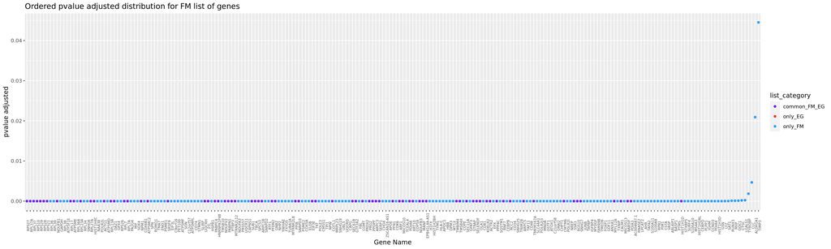

```r
# Represent the data with pval scale
ggplot(data = genes_FM_list, aes(x=gene, y=p_val_adj, col=list_category)) +
  geom_point() +
  scale_color_manual(values = color_code) +
  xlab(label = "Gene Name") +
  ylab(label = "pvalue adjusted") +
  ggtitle(label = "Ordered pvalue adjusted distribution for FM list of genes") +
  theme(axis.text.x = element_text(angle = 90, size = 6))
```

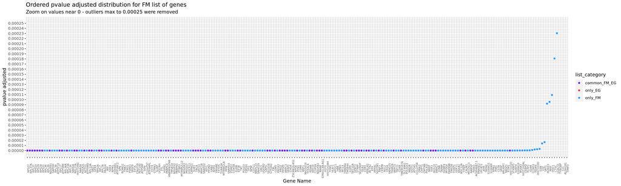

```r
# Zoom in
ggplot(data = genes_FM_list, aes(x=gene, y=p_val_adj, col=list_category)) +
  geom_point() +
  scale_color_manual(values = color_code) +
  xlab(label = "Gene Name") +
  ylab(label = "pvalue adjusted") +
  coord_cartesian(ylim= c(0, 0.00025)) +
  scale_y_continuous(breaks=seq(0,0.00025, 0.00001)) +
  ggtitle(label = "Ordered pvalue adjusted distribution for FM list of genes",
          subtitle = "Zoom on values near 0 - outliers max to 0.00025 were removed") +
  theme(axis.text.x = element_text(angle = 90, size = 6))
```

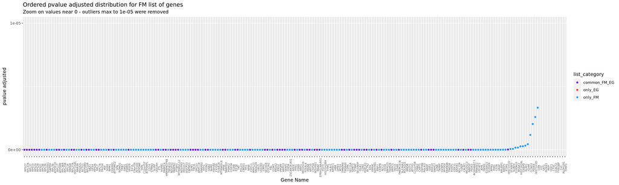

```r
# Zoom in
ggplot(data = genes_FM_list, aes(x=gene, y=p_val_adj, col=list_category)) +
  geom_point() +
  scale_color_manual(values = color_code) +
  xlab(label = "Gene Name") +
  ylab(label = "pvalue adjusted") +
  coord_cartesian(ylim= c(0, 0.00001)) +
  scale_y_continuous(breaks=seq(0,0.00025, 0.00001)) +
  ggtitle(label = "Ordered pvalue adjusted distribution for FM list of genes",
          subtitle = "Zoom on values near 0 - outliers max to 1e-05 were removed") +
  theme(axis.text.x = element_text(angle = 90, size = 6))
```

As we can’t see much, we try with the logarithm scale.

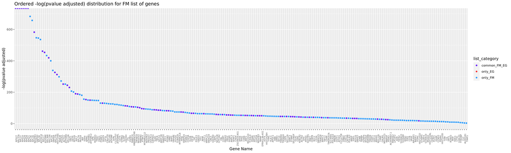

```r
# Represent the data with -log scale
ggplot(data = genes_FM_list, aes(x=gene, y=minus_log_p_val_adj, col=list_category)) +
  geom_point() +
  scale_color_manual(values = color_code) +
  xlab(label = "Gene Name") +
  ylab(label = "-log(pvalue adjusted)") +
  coord_cartesian(ylim= c(0, 700)) +
  ggtitle(label = "Ordered -log(pvalue adjusted) distribution for FM list of genes") +
  theme(axis.text.x = element_text(angle = 90, size = 6))
```

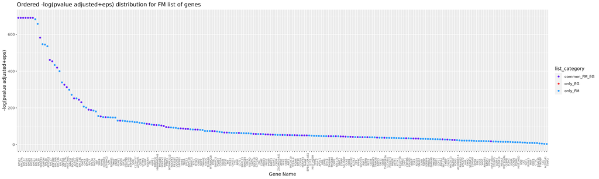

```r
# Represent the data with -log scale +eps
ggplot(data = genes_FM_list, aes(x=gene, y=minus_log_p_val_adj_eps, col=list_category)) +
  geom_point() +
  scale_color_manual(values = color_code) +
  xlab(label = "Gene Name") +
  ylab(label = "-log(pvalue adjusted+eps)") +
  coord_cartesian(ylim= c(0, 700)) +
  ggtitle(label = "Ordered -log(pvalue adjusted+eps) distribution for FM list of genes") +
  theme(axis.text.x = element_text(angle = 90, size = 6))
```

When we look at the list of genes extracted with FM method, it doesn’t seems to have a clear delimitation in pvalue between the genes common with EG and the genes found only with FM.

# pValue distribution (pSNP5 method) of list of genes extracted with EpiGIFT method (174 genes)

```r
require(data.table)
pval5 <- as.data.frame(fread("/shared/ifbstor1/projects/strength_field_u/Epigenetics/CTRL_DON/BinFullData/pval5.csv"))

genes_EG_list$pSNP5 <- pval5[pval5[,1] %in% genes_EG_list$GeneName,2] # logical vector that corresponds to the vector on the left
genesFMpSNP5 <- pval5[pval5[,1] %in% genes_FM_list$gene,]
genes_FM_list$pSNP5 <- genesFMpSNP5[match(genes_FM_list$gene, genesFMpSNP5[,1]),2]
```

```r
# Reorder rows by ascending order of pSNP5
genes_EG_list = genes_EG_list %>% dplyr::arrange(pSNP5)
genes_order = genes_EG_list$GeneName
genes_EG_list$GeneName = factor(genes_EG_list$GeneName , levels = genes_order)
```

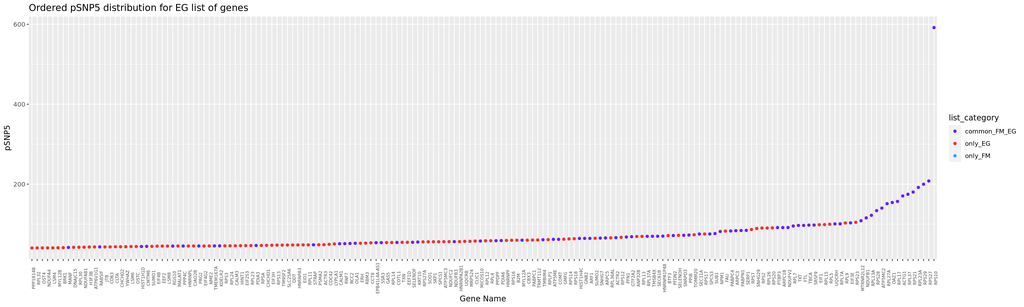

```r
# Represent the data
ggplot(data = genes_EG_list, aes(x=GeneName, y=pSNP5, col=list_category)) +
  geom_point() +
  scale_color_manual(values = color_code) +
  xlab(label = "Gene Name") +
  ylab(label = "pSNP5") +
  ggtitle(label = "Ordered pSNP5 distribution for EG list of genes") +
  theme(axis.text.x = element_text(angle = 90, size = 6))
```

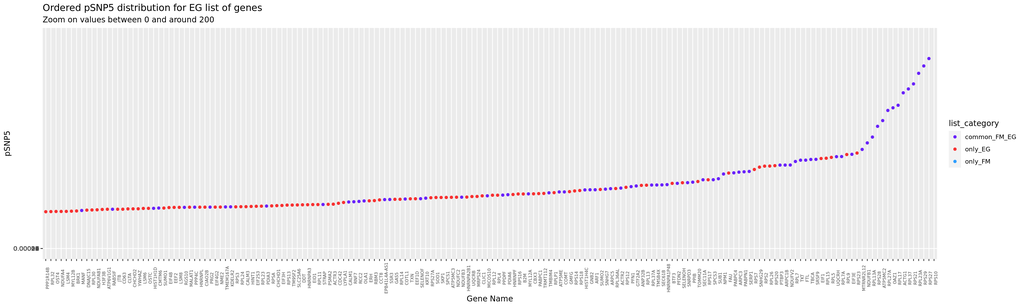

```r
# Zoom in
ggplot(data = genes_EG_list, aes(x=GeneName, y=pSNP5, col=list_category)) +
  geom_point() +
  scale_color_manual(values = color_code) +
  xlab(label = "Gene Name") +
  ylab(label = "pSNP5") +
  coord_cartesian(ylim= c(0, 230)) +
  scale_y_continuous(breaks=seq(0,0.00025, 0.00001)) +
  ggtitle(label = "Ordered pSNP5 distribution for EG list of genes",
          subtitle = "Zoom on values between 0 and around 200") +
  theme(axis.text.x = element_text(angle = 90, size = 6))
```

# pValue distribution (pSNP1 method) of list of genes extracted with EpiGIFT method (174 genes)

```r
pval1 <- as.data.frame(fread("/shared/ifbstor1/projects/strength_field_u/Epigenetics/CTRL_DON/BinFullData/pval1.csv"))

# need to take the -log(pSNP1)
# add epsilon value to avoid Inf values
pval1[,3] <- -log(pval1[,2])
eps <- 1e-150
pval1[,4] <- -log(pval1[,2]+eps)

colnames(pval1) <- c("GeneName", "pSNP1", "-log(pSNP1)", "-log(pSNP1+eps)")

genesEGpSNP1 <- pval1[pval1[,1] %in% genes_EG_list$GeneName,]
genes_EG_list$pSNP1 <- genesEGpSNP1[match(genes_EG_list$GeneName, genesEGpSNP1[,1]),4] #4th column to take the -log(pSNP1+eps)

genesFMpSNP1 <- pval1[pval1[,1] %in% genes_FM_list$gene,]
genes_FM_list$pSNP1 <- genesFMpSNP1[match(genes_FM_list$gene, genesFMpSNP1[,1]),4] #4th column to take the -log(pSNP1+eps)
```

```r
# Reorder rows by ascending order of pSNP1
genes_EG_list = genes_EG_list %>% dplyr::arrange(pSNP1)
genes_order = genes_EG_list$GeneName
genes_EG_list$GeneName = factor(genes_EG_list$GeneName , levels = genes_order)
```

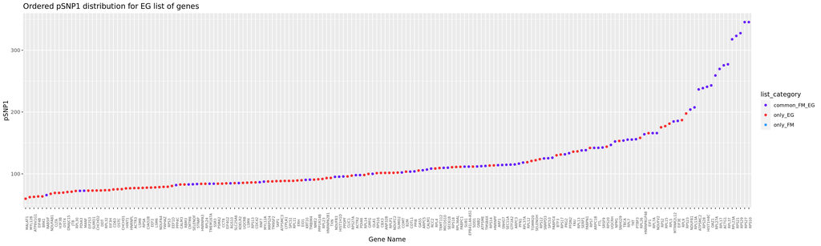

```r
# Represent the data
ggplot(data = genes_EG_list, aes(x=GeneName, y=pSNP1, col=list_category)) +
  geom_point() +
  scale_color_manual(values = color_code) +
  xlab(label = "Gene Name") +
  ylab(label = "pSNP1") +
  ggtitle(label = "Ordered pSNP1 distribution for EG list of genes") +
  theme(axis.text.x = element_text(angle = 90, size = 6))
```

# pValue distribution (pSNP4 method) of list of genes extracted with EpiGIFT method (174 genes)

```r
pval4 <- as.data.frame(fread("/shared/ifbstor1/projects/strength_field_u/Epigenetics/CTRL_DON/BinFullData/pval4.csv"))

genesEGpSNP4 <- pval4[pval4[,1] %in% genes_EG_list$GeneName,]
genes_EG_list$pSNP4 <- genesEGpSNP4[match(genes_EG_list$GeneName, genesEGpSNP4[,1]),2]

genesFMpSNP4 <- pval4[pval4[,1] %in% genes_FM_list$gene,]
genes_FM_list$pSNP4 <- genesFMpSNP4[match(genes_FM_list$gene, genesFMpSNP4[,1]),2]
```

```r
# Reorder rows by ascending order of pSNP1
genes_EG_list = genes_EG_list %>% dplyr::arrange(pSNP4)
genes_order = genes_EG_list$GeneName
genes_EG_list$GeneName = factor(genes_EG_list$GeneName , levels = genes_order)
```

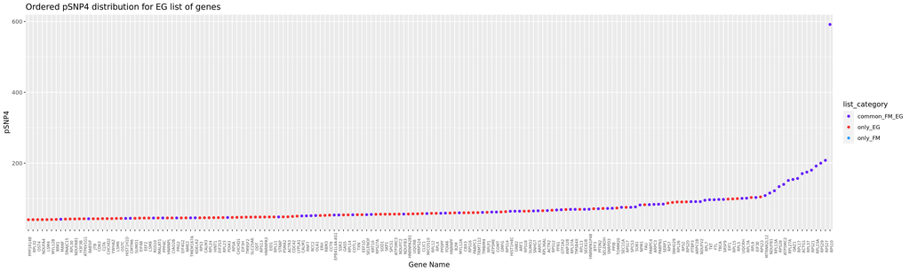

```r
# Represent the data
ggplot(data = genes_EG_list, aes(x=GeneName, y=pSNP4, col=list_category)) +
  geom_point() +
  scale_color_manual(values = color_code) +
  xlab(label = "Gene Name") +
  ylab(label = "pSNP4") +
  ggtitle(label = "Ordered pSNP4 distribution for EG list of genes") +
  theme(axis.text.x = element_text(angle = 90, size = 6))
```

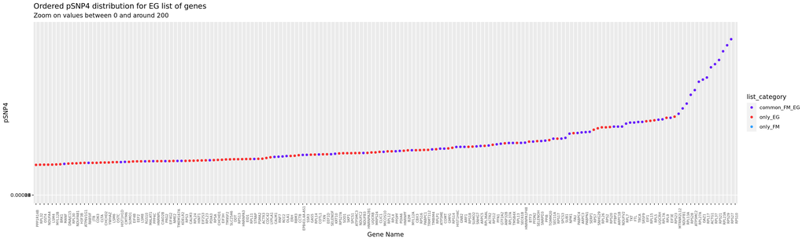

```r
# Zoom in
ggplot(data = genes_EG_list, aes(x=GeneName, y=pSNP4, col=list_category)) +
  geom_point() +
  scale_color_manual(values = color_code) +
  xlab(label = "Gene Name") +
  ylab(label = "pSNP4") +
  coord_cartesian(ylim= c(0, 220)) +
  scale_y_continuous(breaks=seq(0,0.00025, 0.00001)) +
  ggtitle(label = "Ordered pSNP4 distribution for EG list of genes",
          subtitle = "Zoom on values between 0 and around 200") +
  theme(axis.text.x = element_text(angle = 90, size = 6))
```

The values of $pSNP4$ and $pSNP5$ are similar (same range), whereas the values of $pSNP1$ differs (due to the equations used for each case). Also, as the plots represent, red points are mostly located to the left side of the gragh indicating slightly lower values, compared to the blue points (common genes) that have higher $pSNP$ values and be located on the right side.

# pvalue distribution of list of genes from FindMarkers and EpiGIFT

**Step 1 : table with all the genes of both list (total = 316 genes) and the corresponding FindMarkers pvalue**  
We manually calculate pvalue for those genes in scRNAseq_EpiGIFT_Seurat_InvestigationCompare_ListGenes.Rmd.  
We join the table to have a complete one with all the genes of the three categories.

NB : for FM method, a good pvalue is really close to 0.  
When take the transformation $-\log()$, a good value is the one that is really high.

```r
# Genes only EG
# dir = pic_last_dir(paste0(directory, "exp/", "scRNAseq_EpiGIFT_Seurat_InvestigationCompare_ListGenes/"))
# genes_EG_FMpval = readRDS(paste0(dir, "/", "EG_FindMarkerscalcul_CTRLDON.rds"))
# Giota's direcrtory
genes_EG_FMpval = readRDS("/shared/ifbstor1/projects/strength_field_u/Epigenetics/CTRL_DON/Git/exp/EG_FindMarkerscalcul_CTRLDON.rds")

print("pval adjusted summary for EG genes with FM method")
```

```
## [1] "pval adjusted summary for EG genes with FM method"
```

```r
summary(genes_EG_FMpval$p_val_adj)
```

```
##    Min. 1st Qu.  Median    Mean 3rd Qu.    Max.
##    0.00    0.00    0.00   35.36    0.00 3005.33
```

```r
genes_EG_FMpval = genes_EG_FMpval %>%
  dplyr::select(gene, p_val_adj) %>%
  dplyr::mutate(list_category = case_when(gene %in% common_list ~ "common_FM_EG",
                                          gene %in% only_EG_list ~ "only_EG"))

# Genes only FM and common EG FM
genes_FM = genes_FM_list %>% dplyr::select(gene, p_val_adj, list_category)

# Join the table
eps <- 1e-300 #define the epsilon value for the -log() transformation

tab_all_genes = full_join(x = genes_EG_FMpval %>% dplyr::filter(list_category != "common_FM_EG"),
                          y = genes_FM, by = c("gene", "p_val_adj", "list_category"))
tab_all_genes = tab_all_genes %>%
  dplyr::rename("pvalueFM" = "p_val_adj") %>%
  dplyr::mutate(minus_log_pvalueFM = -log(pvalueFM+eps))

# Display the result
# tab_all_genes %>%
#   kable() %>%
#   kable_styling()

# save intermediate table
# saveRDS(tab_all_genes, paste0(directory_output, "tab_all_genes_pvalueFM.rds"))
```

**Step2 : Add EG pvalue for all the genes**

We join to the table the $pSNP5$, $pSNP1$ and $pSNP4$ values as calculated by EpiGift.

NB : All the $pSNP$ values are expressed in the $-log()$ scale (high value of $pSNP$ is good).

```r
# Add pSNP5 in the global table
genes_pSNP5 <- pval5[pval5[,1] %in% tab_all_genes$gene,]
tab_all_genes$pSNP5 <- genes_pSNP5[match(tab_all_genes$gene, genes_pSNP5[,1]),2]

print("pSNP5 summary for FM genes")
```

```
## [1] "pSNP5 summary for FM genes"
```

```r
summary(tab_all_genes$pSNP5[tab_all_genes$list_category=="only_FM"])
```

```
##    Min. 1st Qu.  Median    Mean 3rd Qu.    Max.
##  0.1079  3.0717 10.9762 14.1125 23.9063 39.4676
```

```r
# Add pSNP1 in the global table
genes_pSNP1 <- pval1[pval1[,1] %in% tab_all_genes$gene,]
tab_all_genes$pSNP1 <- genes_pSNP1[match(tab_all_genes$gene, genes_pSNP1[,1]),4]

print("pSNP1 summary for FM genes")
```

```
## [1] "pSNP1 summary for FM genes"
```

```r
summary(tab_all_genes$pSNP1[tab_all_genes$list_category=="only_FM"])
```

```
##    Min. 1st Qu.  Median    Mean 3rd Qu.    Max.
##   1.630   9.938  32.606  33.924  53.772 101.639
```

```r
# Add pSNP4 in the global table
genes_pSNP4 <- pval4[pval4[,1] %in% tab_all_genes$gene,]
tab_all_genes$pSNP4 <- genes_pSNP4[match(tab_all_genes$gene, genes_pSNP4[,1]),2]

print("pSNP4 summary for FM genes")
```

```
## [1] "pSNP4 summary for FM genes"
```

```r
summary(tab_all_genes$pSNP4[tab_all_genes$list_category=="only_FM"])
```

```
##    Min. 1st Qu.  Median    Mean 3rd Qu.    Max.
##   0.208   3.355  11.007  14.266  23.906  39.468
```

```r
# Display the result
tab_all_genes %>%
kable() %>%
kable_styling() %>%
scroll_box(width = "100%", height = "500px")
```

| gene | pvalueFM | list_category | minus_log_pvalueFM | pSNP5 | pSNP1 | pSNP4 |
| --- | --- | --- | --- | --- | --- | --- |
| CDC42 | 0.0021133 | only_EG | 6.1595178 | 49.5170181 | 86.220972 | 49.5170181 |
| RPL11 | 0.0077293 | only_EG | 4.8627333 | 48.1126665 | 88.720536 | 48.1269556 |
| RPL5 | 0.0000000 | only_EG | 133.6892007 | 99.7926503 | 181.146116 | 99.7926503 |
| JTB | 0.0000000 | only_EG | 18.7245375 | 43.0071290 | 71.125477 | 43.0071290 |
| GAS5 | 0.0559965 | only_EG | 2.8824661 | 53.8671025 | 105.333288 | 53.8671025 |
| TOMM20 | 0.0000000 | only_EG | 40.1837592 | 73.3552337 | 120.878828 | 73.3552337 |
| RPS7 | 0.0000000 | only_EG | 126.9630831 | 86.5340828 | 141.931267 | 87.1634361 |
| OST4 | 4.3886800 | only_EG | -1.4790285 | 40.5528661 | 69.662946 | 40.5528661 |
| RPS27A | 0.0000000 | only_EG | 24.1613187 | 55.5882081 | 97.104201 | 55.5886108 |
| ACTR3 | 0.0000000 | only_EG | 20.3150563 | 48.5278767 | 77.029944 | 48.5278767 |
| ATP5MC3 | 0.0000000 | only_EG | 44.0652230 | 56.0509871 | 88.336705 | 56.0509871 |
| HNRNPA3 | 0.0000000 | only_EG | 40.3582282 | 47.9378517 | 83.845863 | 47.9378517 |
| SUMO1 | 0.0000000 | only_EG | 19.0781854 | 44.3105204 | 72.942731 | 44.3105204 |
| BRK1 | 0.0035260 | only_EG | 5.6475851 | 41.1070407 | 63.492073 | 41.1070428 |
| RPL32 | 746.5636518 | only_EG | -6.6154809 | 40.4245191 | 73.532674 | 40.5156155 |
| RPL15 | 0.0000000 | only_EG | 124.5260868 | 98.8511332 | 177.190718 | 99.0654582 |
| RPSA | 0.0004618 | only_EG | 7.6804331 | 46.6755603 | 77.315208 | 46.6755625 |
| RPL14 | 0.0000001 | only_EG | 15.9620125 | 53.8982544 | 98.127335 | 54.0333245 |
| SPCS1 | 0.0000000 | only_EG | 33.4481028 | 55.9122628 | 88.657261 | 55.9122628 |
| RPL24 | 823.6475420 | only_EG | -6.7137427 | 45.7816794 | 83.963981 | 45.8633540 |
| RPL9 | 0.0000000 | only_EG | 150.6005664 | 102.8943379 | 186.959715 | 103.0964517 |
| OSTC | 0.0000170 | only_EG | 10.9809043 | 43.9671209 | 75.117851 | 43.9671209 |
| LSM6 | 0.0000000 | only_EG | 32.6964866 | 43.8848991 | 78.081305 | 43.8848991 |
| BTF3 | 0.0000000 | only_EG | 17.4240890 | 71.3204782 | 130.034223 | 71.3317487 |
| RPS23 | 0.0000000 | only_EG | 197.5697709 | 104.5179160 | 197.598998 | 104.6293232 |
| HINT1 | 307.4442493 | only_EG | -5.7282938 | 46.0487733 | 76.476703 | 46.0986050 |
| SKP1 | 0.0000001 | only_EG | 16.4059626 | 55.8823657 | 88.234193 | 55.8823657 |
| RPS14 | 0.0000001 | only_EG | 16.1791470 | 63.0327246 | 113.398018 | 63.0994193 |
| CLIC1 | 0.0000000 | only_EG | 18.0443382 | 57.6553750 | 95.866720 | 57.6553750 |
| RPS18 | 0.0000000 | only_EG | 45.7972626 | 63.4946254 | 110.716869 | 64.3661443 |

[output cut: 286 more lines]

```r
# save intermediate table
# saveRDS(tab_all_genes, "/shared/ifbstor1/projects/strength_field_u/Epigenetics/CTRL_DON/Git/exp/tab_all_genes_pvalues.rds")
```

**Step3 : Graphical representation with $pSNP$ on y axis and pvalueFM on x axis**

The scale of $x$ and $y$ axis is $-\log()$.

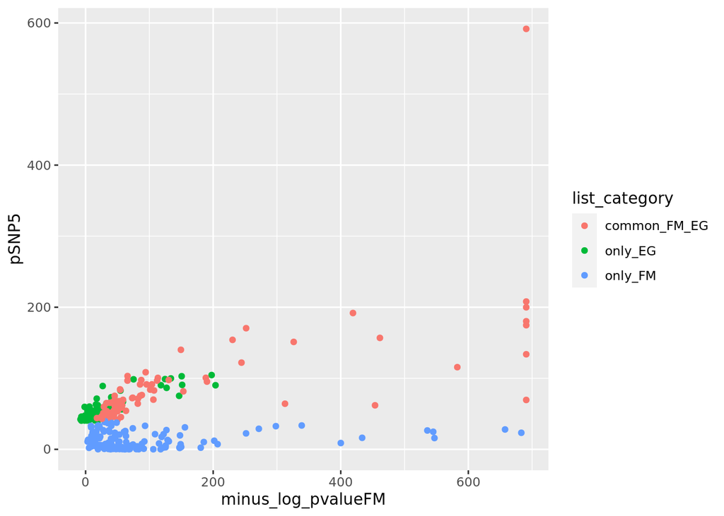

```r
# Create a table with name of the gene, list_category, pvalue in FM, pvalue in EG
# gene list_category (common, onlyEG, onlyFM) pvalueEG pvalueFM

# pSNP5 on y axis, -log(pvalueFM+eps) on x axis and different colors for list_category

ggplot(data = tab_all_genes, aes(x=minus_log_pvalueFM, y=pSNP5, col = list_category)) +
  geom_point() +
  scale_fill_manual(values = color_code, limits = force)
```

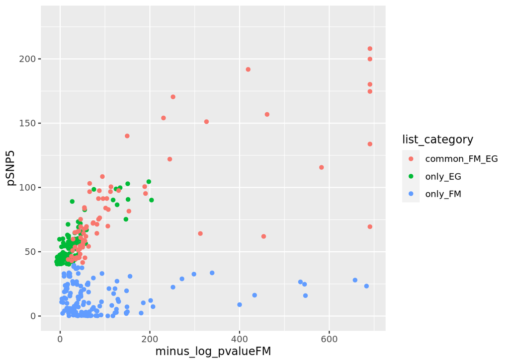

```r
# Zoom in
ggplot(data = tab_all_genes, aes(x=minus_log_pvalueFM, y=pSNP5, col = list_category)) +
  geom_point() +
  scale_fill_manual(values = color_code, limits = force) +
  ylim(0,230)
```

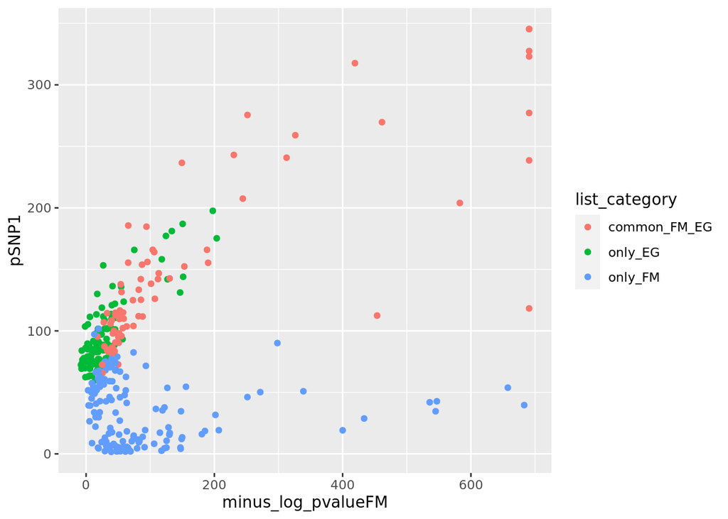

```r
# pSNP1 on y axis, pvalueFM on x axis and different colors for list_category

ggplot(data = tab_all_genes, aes(x=minus_log_pvalueFM, y=pSNP1, col = list_category)) +
  geom_point() +
  scale_fill_manual(values = color_code, limits = force)
```

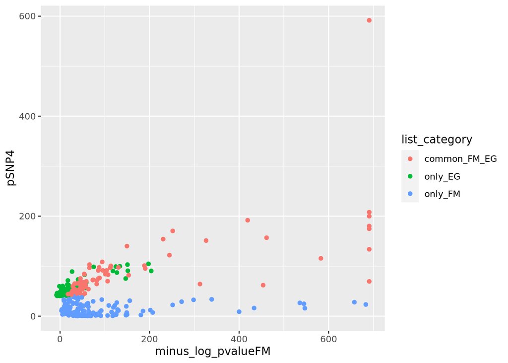

```r
# pSNP4 on y axis, pvalueFM on x axis and different colors for list_category

ggplot(data = tab_all_genes, aes(x=minus_log_pvalueFM, y=pSNP4, col = list_category)) +
  geom_point() +
  scale_fill_manual(values = color_code, limits = force)
```

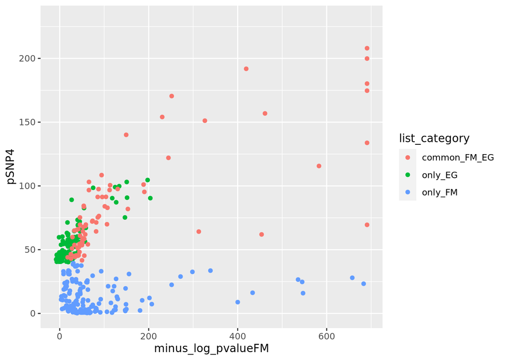

```r
# Zoom in
ggplot(data = tab_all_genes, aes(x=minus_log_pvalueFM, y=pSNP4, col = list_category)) +
  geom_point() +
  scale_fill_manual(values = color_code, limits = force) +
  ylim(0,230)
```

# Conclusion

To sum up, genes detected by both methods (pink points) or only by EpiGift (green points) tend to have higher $pSNP$ values compared to genes that are identified only by FindMarkers.

```r
end_time = Sys.time()
cat("Total execution time : ", as.numeric (end_time - start_time, units = "mins"), "minutes")
```

```
## Total execution time :  0.2113321 minutes
```

```r
# Clean working space and memory
rm(list = ls())
gc()
```

```
##           used  (Mb) gc trigger  (Mb) max used  (Mb)
## Ncells 3475991 185.7    5151638 275.2  5151638 275.2
## Vcells 5981792  45.7   12255594  93.6  9144603  69.8
```